# Compute distance to river mouth

Here, we show how we compute distance to river mouth for all fishing operations.

## Setup

```r
library(renv)
renv::load()
library(targets)
library(here)
tar_config_set(
  store = here::here("_targets")
)
library(ggplot2)
library(dplyr)
library(sf)
library(patchwork)
devtools::load_all()
riversea::nice_theme()
```

## Snapping river survey stations to the network

### Catchments

We focus on four catchments: Loire, Ardour-Garonne, Seine and Escaut-Somme. We attribute stations to catchment using the BD Topage’s polygones delimiting hydrographic basins.

```r
network_river <- tar_read(river_network)
river_stations <- tar_read(inland_operations_snapped) |>
  filter(survey == "river")
basin <- tar_read(basin)
district_kept <- c("Loire", "Ardour-Garonne", "Seine", "Escaut-Somme")

cols <- c(
  Loire = "steelblue",
  "Ardour-Garonne" = "firebrick",
  Seine = "darkgreen",
  "Escaut-Somme" = "orange"
)

basin_kept <- basin |> filter(district %in% district_kept)
in_scope <- river_stations |> filter(district %in% district_kept)
river_coords <- network_river$nodes |>
  sf::st_as_sf() |>
  sf::st_transform(4326) |>
  sf::st_coordinates()
```

We can visualise the catchments of interest as wells the corresponding stations.

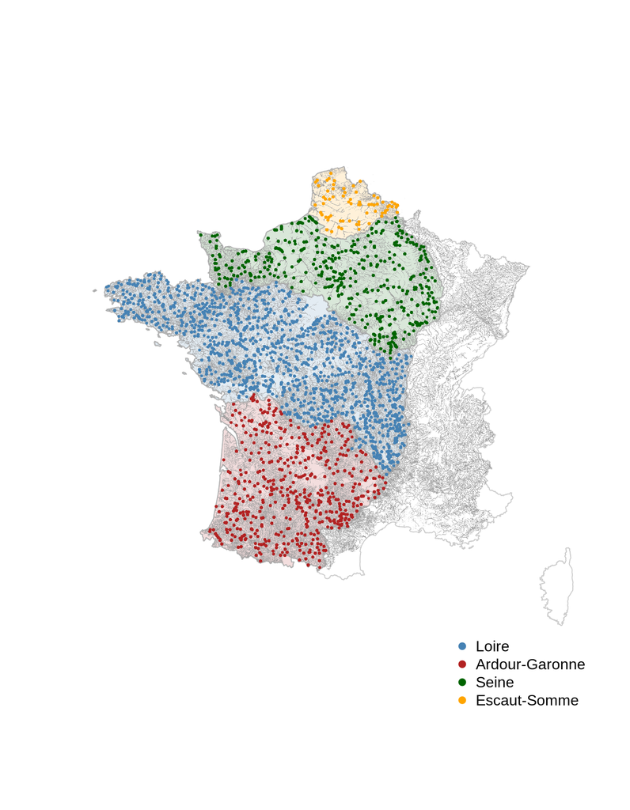

```r
plot(st_geometry(basin), col = NA, border = "grey80")
plot(
  st_geometry(basin_kept),
  col = scales::alpha(cols[basin_kept$district], 0.15),
  border = "grey70",
  add = TRUE
)
points(
  river_coords[, "X"],
  river_coords[, "Y"],
  col = scales::alpha("grey60", 0.25),
  pch = ".",
  cex = 0.5
)
points(
  in_scope$longitude,
  in_scope$latitude,
  col = cols[in_scope$district],
  pch = 19,
  cex = 0.3
)
legend("bottomright", legend = names(cols), col = cols, pch = 19, bty = "n")
```

We can have a look at how many stations we have per catchments

```r
count(river_stations, district) |>
  filter(district %in% district_kept) |>
  arrange(n) |>
  knitr::kable()
```

| district | n |
| --- | --- |
| Escaut-Somme | 495 |
| Seine | 3241 |
| Ardour-Garonne | 4378 |
| Loire | 6245 |

Next, we evaluate the snapping quality for those catchments.

### Evaluate snapping quality

We snap fish-monitoring stations to the network hydrographic network. Because snapping requires precision, we use the network with line geometry `river_network_geo`. We can evaluate the snapping quality through the snapping distance, that is, how far the station was from the closest point in the river network. Short distances indicate confident snapping.

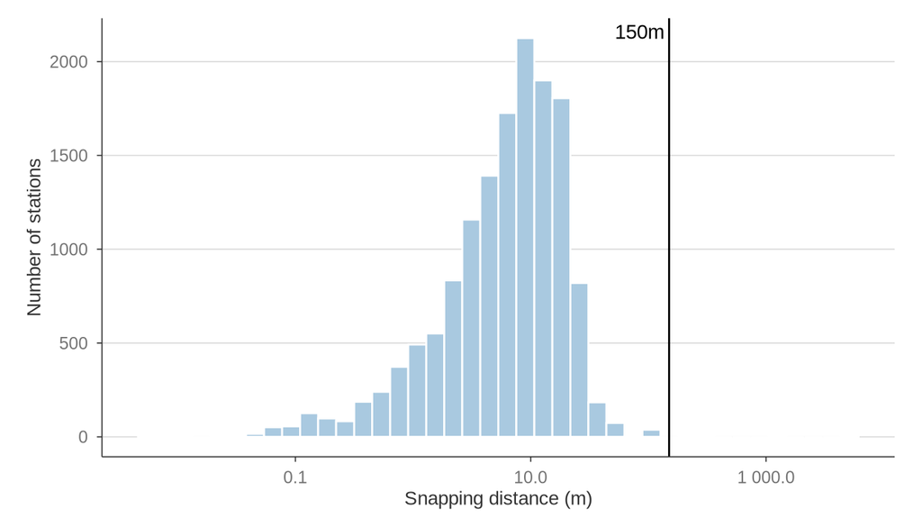

```r
threshold <- 150
stations_selected <- river_stations |>
  filter(district %in% district_kept)

ggplot(stations_selected, aes(x = snap_dist_m)) +
  geom_histogram(fill = "#a9c9e0", color = "white", bins = 40) +
  geom_vline(xintercept = threshold) +
  annotate(
    "text",
    x = threshold, y = Inf, label = paste0(threshold, "m"),
    hjust = 1.1, vjust = 1.5
  ) +
  scale_x_continuous(trans = "log10", labels = scales::label_number()) +
  labs(x = "Snapping distance (m)", y = "Number of stations")
```

```r
n_bad_snap <- sum(stations_selected$snap_dist_m > threshold)
```

We see that the vast majority of stations are well-snapped to the river network. In particular, we have only with 9 a snapping distance greater than 150 meters.

### Adding a network missing edge (Nantes)

While investigating, one component near the Vendée coast appeared disconnected from the rest of the Loire basin, despite sitting inside it. That led this component to be disconnected from any river mouth. After checking, we found two points that were unlinked but suspiciously close to one another, so we decided to investigate where they were.

```r
river_network_full <- tar_read(river_network_full)
network_before <- river_network_full
network_before$edges <- network_before$edges |>
  filter(!(from == 614458 & to == 614552))

comp_before <- igraph::components(igraph::graph_from_edgelist(
  as.matrix(network_before$edges[c("from", "to")]),
  directed = FALSE
))
vendee_comp_nodes <- which(
  comp_before$membership == comp_before$membership[595001]
)
main_sf <- river_network_full$nodes |>
  filter(
    node_id %in% which(comp_before$membership == which.max(comp_before$csize))
  ) |>
  sf::st_as_sf()
vendee_sf <- river_network_full$nodes |>
  filter(node_id %in% vendee_comp_nodes) |>
  sf::st_as_sf()

gap_dist_m <- as.numeric(sf::st_distance(
  vendee_sf, main_sf[sf::st_nearest_feature(vendee_sf, main_sf), ],
  by_element = TRUE
))

gap_pts <- river_network_full$nodes |>
  filter(node_id %in% c(614458, 614552)) |>
  sf::st_as_sf() |>
  sf::st_transform(4326) |>
  mutate(label = c("Vendée-side node", "Main-network node"))

leaflet::leaflet(gap_pts) |>
  leaflet::addProviderTiles(leaflet::providers$Esri.WorldTopoMap) |>
  leaflet::addCircleMarkers(
    color = c("firebrick", "steelblue"),
    radius = 8,
    label = ~label
  ) |>
  leaflet::setView(
    lng = mean(sf::st_coordinates(gap_pts)[, 1]),
    lat = mean(sf::st_coordinates(gap_pts)[, 2]),
    zoom = 15
  )
```

[interactive chart not shown]

These points represent the confluence between the Loire and the Sèvre Nantaise. Restoring this missing link allowed us to recover the entire connected component. This operation is documented in `patch_river_network()`.

## Distance to river mouth

Here we have everything to compute the distance to the river mouth for river stations at least.

### River operations

We group our stations per catchment, and identify for each catchment transitions point between freshwater and marine areas.

```r
river_mouth_district <- tar_read(river_mouth_district)
mouths_kept <- river_mouth_district |>
  filter(matched, district %in% district_kept)
mouth_coords <- sf::st_coordinates(mouths_kept)
```

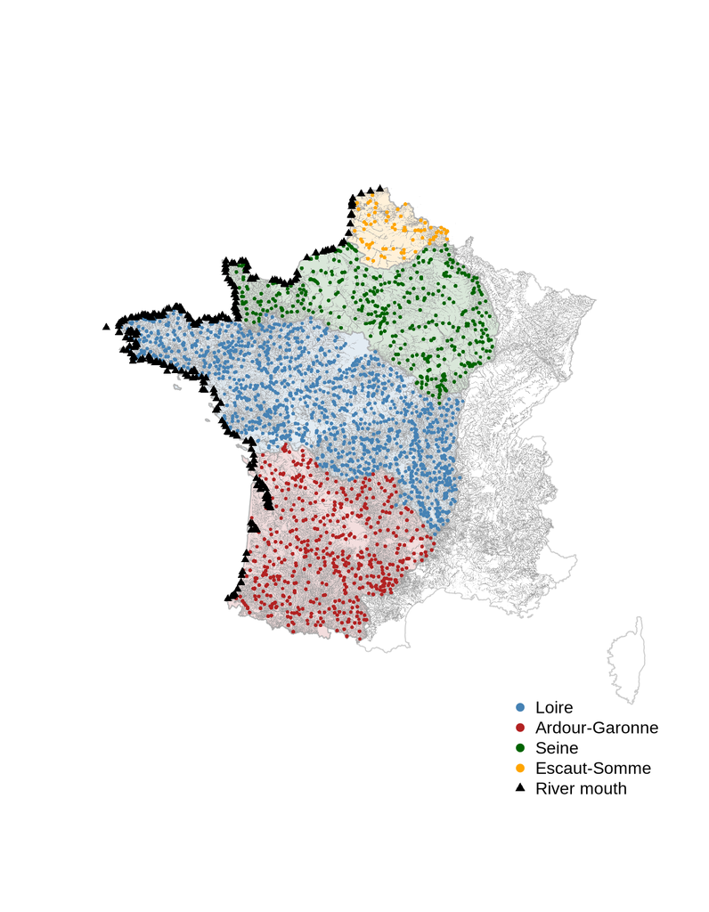

```r
plot(st_geometry(basin), col = NA, border = "grey80")
plot(
  st_geometry(basin_kept),
  col = scales::alpha(cols[basin_kept$district], 0.15),
  border = "grey70",
  add = TRUE
)
points(
  river_coords[, "X"],
  river_coords[, "Y"],
  col = scales::alpha("grey60", 0.25),
  pch = ".",
  cex = 0.5
)
points(
  in_scope$longitude,
  in_scope$latitude,
  col = cols[in_scope$district],
  pch = 19,
  cex = 0.3
)
points(
  mouth_coords[, "X"], mouth_coords[, "Y"],
  col = "black", pch = 17, cex = 0.8
)
legend(
  "bottomright",
  legend = c(names(cols), "River mouth"),
  col = c(cols, "black"),
  pch = c(rep(19, length(cols)), 17),
  bty = "n"
)
```

We then compute for each station the channel-length distance to the closest river mouth of its own catchment (so a station can only be matched to a mouth of its own catchment - see `compute_distance_to_mouth()`).

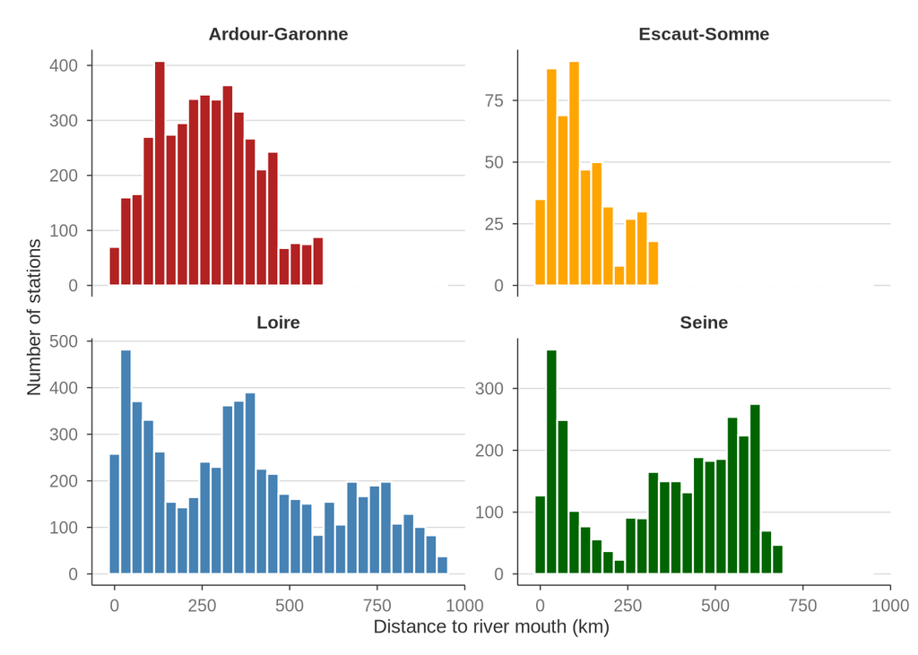

```r
river_distance <- tar_read(distance_to_mouth) |>
  filter(survey == "river")

ggplot(river_distance, aes(x = dist_mouth_m / 1000, fill = district)) +
  geom_histogram(bins = 30, color = "white") +
  scale_fill_manual(values = cols, guide = "none") +
  facet_wrap(~district, scales = "free_y") +
  labs(x = "Distance to river mouth (km)", y = "Number of stations")
```

```r
river_distance |>
  group_by(district) |>
  summarise(
    n = n(),
    median_km = round(median(dist_mouth_m) / 1000, 1),
    max_km = round(max(dist_mouth_m) / 1000, 1)
  ) |>
  arrange(median_km) |>
  knitr::kable()
```

| district | n | median_km | max_km |
| --- | --- | --- | --- |
| Escaut-Somme | 495 | 101.4 | 311.8 |
| Ardour-Garonne | 4378 | 257.8 | 606.7 |
| Loire | 6245 | 348.2 | 936.1 |
| Seine | 3241 | 392.7 | 700.7 |

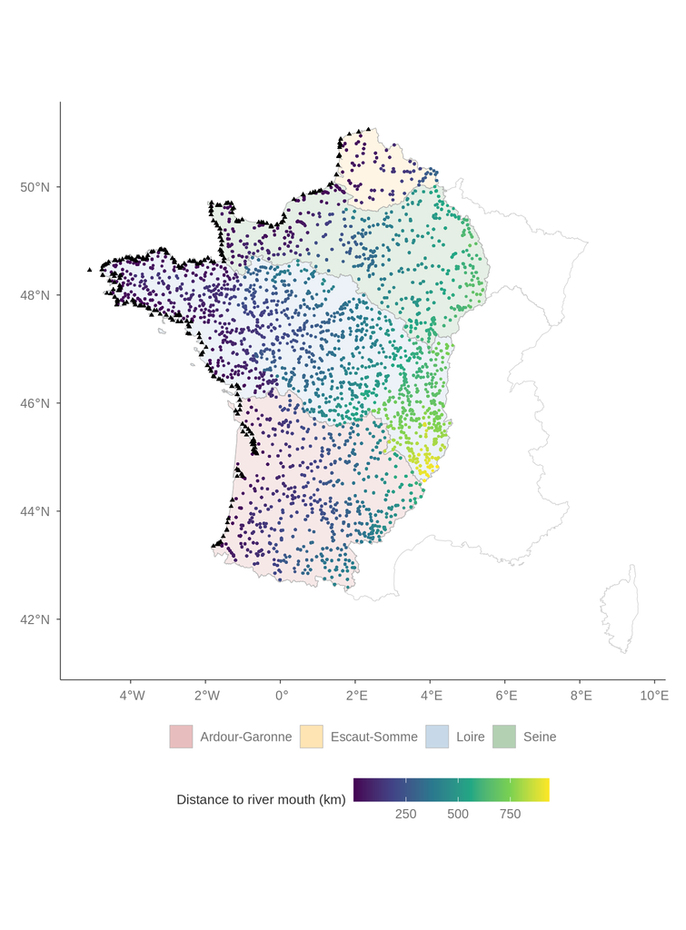

```r
river_coords_df <- as.data.frame(river_coords)
mouth_coords_df <- as.data.frame(mouth_coords)

ggplot() +
  geom_sf(data = basin, fill = NA, color = "grey80") +
  geom_sf(
    data = basin_kept, aes(fill = district), color = "grey70", alpha = 0.10
  ) +
  scale_fill_manual(values = cols, name = NULL) +
  geom_point(
    data = river_distance,
    aes(longitude, latitude, color = dist_mouth_m / 1000),
    size = 0.4
  ) +
  scale_color_viridis_c(name = "Distance to river mouth (km)") +
  geom_point(data = mouth_coords_df, aes(X, Y), shape = 17, size = 1) +
  coord_sf() +
  labs(x = NULL, y = NULL) +
  guides(
    fill = guide_legend(nrow = 1, override.aes = list(alpha = 0.3)),
    color = guide_colorbar(barwidth = 10)
  ) +
  theme(legend.box = "vertical", panel.grid = element_blank())
```

Distances range from a few tens of meters (stations right at the mouth) to under 950km. Escaut-Somme has the shortest distances overall (small, coastal catchment), while Seine stations sit farthest inland on average.

### Sea operations

#### Inland vs. sea-side

For sea operations, we first need to know whether an operation sits upstream or downstream of the river mouth before a distance is even meaningful. One idea: use `basin` (land catchment) vs. `coastal_water` (coastal/transitional water body) - if a point falls in the basin polygon, it’s inland; if in the coastal water polygon, sea-side.

To validate our choice let’s have a look at the Gironde and Loire estuaries.

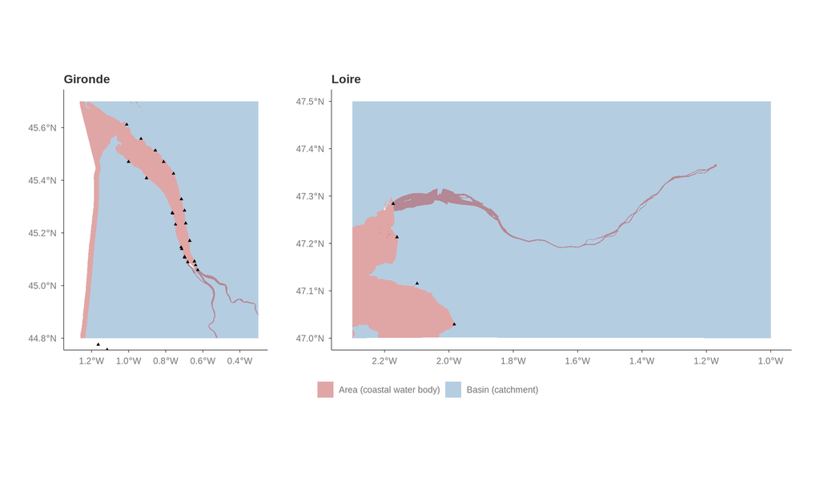

```r
coastal_water <- tar_read(coastal_water)

plot_estuary <- function(name, xlim, ylim) {
  bbox <- st_as_sfc(st_bbox(
    c(xmin = xlim[1], xmax = xlim[2], ymin = ylim[1], ymax = ylim[2]),
    crs = 4326
  ))
  basin_e <- st_intersection(st_make_valid(basin), bbox)
  area_e <- st_intersection(st_make_valid(coastal_water), bbox)

  ggplot() +
    geom_sf(
      data = basin_e, aes(fill = "Basin (catchment)"), color = NA, alpha = 0.4
    ) +
    geom_sf(
      data = area_e, aes(fill = "Area (coastal water body)"),
      color = NA, alpha = 0.4
    ) +
    geom_point(data = mouth_coords_df, aes(X, Y), shape = 17, size = 1) +
    scale_fill_manual(
      name = NULL,
      values = c(
        "Basin (catchment)" = "steelblue",
        "Area (coastal water body)" = "firebrick"
      )
    ) +
    coord_sf(xlim = xlim, ylim = ylim) +
    labs(x = NULL, y = NULL, title = name) +
    theme(panel.grid = element_blank())
}

p_gironde <- plot_estuary("Gironde", c(-1.3, -0.3), c(44.8, 45.7))
p_loire <- plot_estuary("Loire", c(-2.3, -1.0), c(47.0, 47.5))

p_gironde + p_loire +
  plot_layout(guides = "collect") &
  theme(legend.position = "bottom")
```

From what we see there, it is quite clear that the natural delimitation is the basin polygon, whose boundaries fit well with our river mouths. So, to infer whether an operation is inland or sea-side, we check whether it falls within a hydrographic basin: if so, it is inland; if not, it is sea-side.

Let’s see, per survey, how many inland and sea-side operations we have.

```r
operation_location <- tar_read(operation_location)

operation_location |>
  count(survey, inland) |>
  tidyr::pivot_wider(
    names_from = inland,
    values_from = n,
    values_fill = 0,
    names_prefix = "inland_"
  ) |>
  rename(
    inland = inland_TRUE,
    "sea-side" = inland_FALSE,
  ) |>
  knitr::kable()
```

| survey | sea-side | inland |
| --- | --- | --- |
| nurse | 1534 | 4 |
| pomet | 2082 | 4682 |
| river | 0 | 14359 |

#### Catchment attribution

Next, we want to attribute a catchment to the sea operations. We proceed as follows: if the operation is inland, we use the district of the basin it falls in; if the operation is sea-side, we use the district of the closest coastal water body. Here, the question is to define a threshold beyond which we consider that a coastal water body cannot be reliably attributed to an operation. To help us, let’s plot, in the Gironde estuary, the operations farthest from the closest water body.

```r
operation_year_filtered <- tar_read(operation_year_filtered)

outside_sea <- operation_year_filtered |>
  filter(survey != "river") |>
  sf::st_as_sf(
    coords = c("longitude", "latitude"), crs = 4326, remove = FALSE
  ) |>
  sf::st_join(basin["district"], join = sf::st_within) |>
  filter(is.na(district)) |>
  select(-district)

nearest_idx <- sf::st_nearest_feature(outside_sea, coastal_water)
outside_sea <- outside_sea |>
  mutate(dist_km = as.numeric(sf::st_distance(
    outside_sea, coastal_water[nearest_idx, ],
    by_element = TRUE
  )) / 1000)

thresholds <- c(1, 2, 5, 10, 15, 20)
tibble::tibble(threshold_km = thresholds) |>
  mutate(
    pct_matched = round(
      100 * purrr::map_dbl(threshold_km, \(t) mean(outside_sea$dist_km <= t)),
      1
    ),
    n_unmatched = purrr::map_int(
      threshold_km, \(t) sum(outside_sea$dist_km > t)
    )
  ) |>
  knitr::kable()
```

| threshold_km | pct_matched | n_unmatched |
| --- | --- | --- |
| 1 | 77.2 | 824 |
| 2 | 81.6 | 664 |
| 5 | 94.2 | 208 |
| 10 | 99.8 | 7 |
| 15 | 100.0 | 0 |
| 20 | 100.0 | 0 |

Here, a threshold of 10km leaves 7 operations unmatched; however, they can all be clearly attributed to the Gironde district. Raising the threshold to 15km enables us to attribute all operations correctly, so this is the value we select. Raising the threshold further leads to no change, as every operation is already attributed to a district.

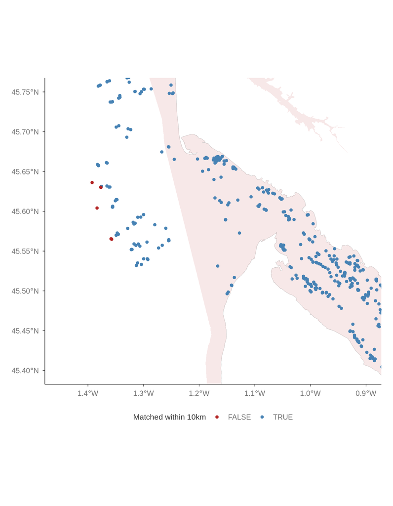

```r
threshold_candidate <- 10
outside_sea <- outside_sea |>
  mutate(matched = dist_km <= threshold_candidate)

ggplot() +
  geom_sf(data = basin, fill = NA, color = "grey80") +
  geom_sf(data = coastal_water, fill = "firebrick", alpha = 0.1, color = NA) +
  geom_sf(data = outside_sea, aes(color = matched), size = 1.3) +
  scale_color_manual(
    values = c(`TRUE` = "steelblue", `FALSE` = "firebrick"),
    name = paste0("Matched within ", threshold_candidate, "km")
  ) +
  coord_sf(xlim = c(-1.45, -0.9), ylim = c(45.4, 45.75)) +
  theme(panel.grid = element_blank())
```

We can now confidently attribute a district to all sea operations, whether they are inland or sea-side. Let’s do it, and investigate, per district (corresponding to the catchments), how many inland and sea-side operations we have.

```r
operation_location |>
  mutate(district = tidyr::replace_na(district, "(sea, no catchment)")) |>
  count(district, inland) |>
  tidyr::pivot_wider(
    names_from = inland,
    values_from = n,
    values_fill = 0,
    names_prefix = "inland_"
  ) |>
  rename(
    inland = inland_TRUE,
    "sea-side" = inland_FALSE,
  ) |>
  arrange(district) |>
  knitr::kable()
```

| district | sea-side | inland |
| --- | --- | --- |
| Ardour-Garonne | 855 | 5117 |
| Escaut-Somme | 197 | 505 |
| Loire | 1800 | 8938 |
| Seine | 764 | 4485 |

#### Inland operations: snapping quality

Sea operations split in two: inland and sea-side. Inland operations are snapped to the river network and their distance to the river mouth is computed as for river operations. Sea-side operations are not on the river network, and Euclidean distance cannot be used directly, because a straight line can cut across land. For this reason, we compute distance along a mesh that excludes land.

First, we check that inland operations are snapped correctly to the river network by looking at their snapping distance.

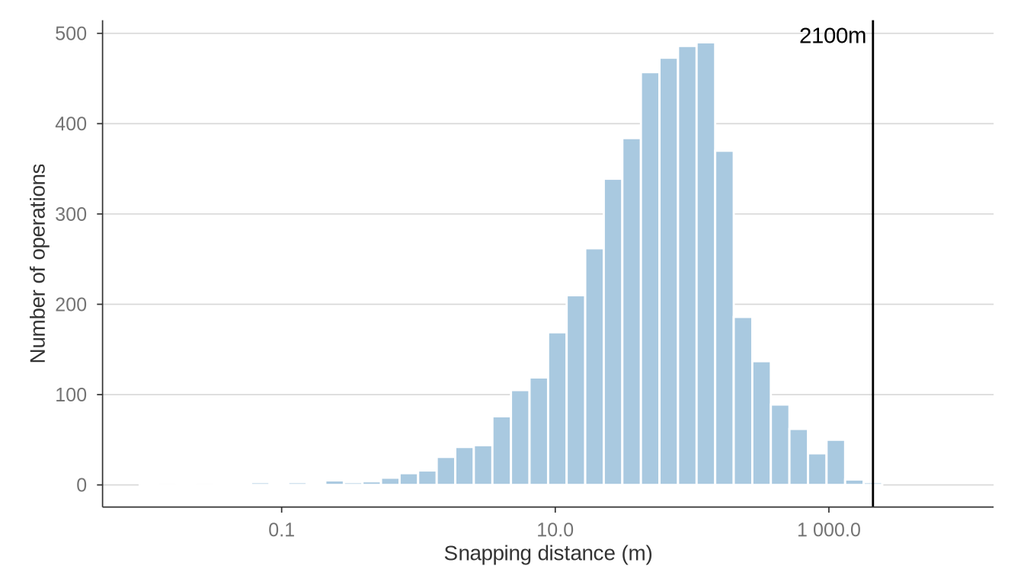

```r
threshold_sea <- 2100
sea_stations_selected <- tar_read(inland_operations_snapped) |>
  filter(survey != "river")

ggplot(sea_stations_selected, aes(x = snap_dist_m)) +
  geom_histogram(fill = "#a9c9e0", color = "white", bins = 40) +
  geom_vline(xintercept = threshold_sea) +
  annotate(
    "text",
    x = threshold_sea, y = Inf, label = paste0(threshold_sea, "m"),
    hjust = 1.1, vjust = 1.5
  ) +
  scale_x_continuous(
    trans = "log10", labels = scales::label_number(),
    expand = expansion(mult = c(0.05, 0.15))
  ) +
  labs(x = "Snapping distance (m)", y = "Number of operations")
```

Because sea survey operations sit in wide estuaries, we expect greater snapping distances than for operations in thin river branches. For this reason, we have raised the threshold to 2100. This value was selected through visual investigation of the Gironde and Seine estuaries, such that all their operations are recovered. This visual investigation allowed us to identify an operation, `61837633`, which turned out to be miscoded inland right at the coast and is now classified sea-side directly in `classify_operation_location()`.

#### Sea-side operations: mesh

We build a water-only mesh (see `build_sea_mesh()`), which we convert into a graph and run the Dijkstra algorithm to compute the distance between the operation and the closest river mouth (per catchment).

Here is the mesh we built. We zoomed in on two coastal areas to show how it follows the land.

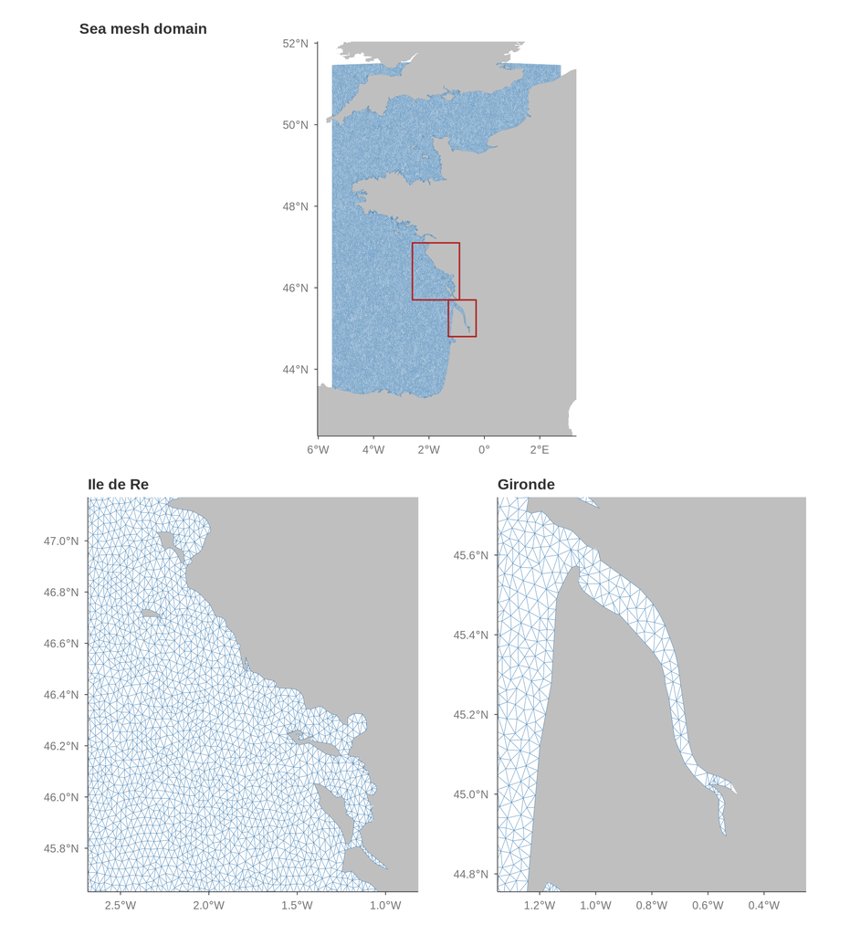

```r
sea_mesh <- tar_read(sea_mesh)
sea_graph <- tar_read(sea_graph)
land_raw <- tar_read(land)
mesh_edges <- sea_mesh_edges(sea_mesh)

zoom_islands <- list(xlim = c(-2.6, -0.9), ylim = c(45.7, 47.1))
zoom_gironde <- list(xlim = c(-1.3, -0.3), ylim = c(44.8, 45.7))

zoom_box <- function(xlim, ylim) {
  st_as_sfc(st_bbox(
    c(xmin = xlim[1], xmax = xlim[2], ymin = ylim[1], ymax = ylim[2]),
    crs = 4326
  ))
}
zoom_boxes <- st_sf(geometry = c(
  zoom_box(zoom_islands$xlim, zoom_islands$ylim),
  zoom_box(zoom_gironde$xlim, zoom_gironde$ylim)
))

p_overview <- ggplot() +
  geom_sf(data = land_raw, fill = "grey75", color = NA) +
  geom_sf(data = mesh_edges, color = "steelblue", linewidth = 0.1) +
  geom_sf(data = zoom_boxes, fill = NA, color = "firebrick", linewidth = 0.6) +
  coord_sf(xlim = c(-5.6, 2.9), ylim = c(42.8, 51.6)) +
  labs(title = "Sea mesh domain", x = NULL, y = NULL) +
  theme(panel.grid = element_blank())

p_islands <- plot_sea_mesh(
  sea_mesh, mesh_edges, zoom_islands$xlim, zoom_islands$ylim,
  "Ile de Re"
)
p_gironde <- plot_sea_mesh(
  sea_mesh, mesh_edges, zoom_gironde$xlim, zoom_gironde$ylim,
  "Gironde"
)

p_overview / (p_islands + p_gironde) +
  patchwork::plot_layout(heights = c(1, 1))
```

The mesh covers water only; land, including islands, is left untriangulated, as desired.

Next, we show, using an example from l’île de Ré, how the mesh-based distance is computed depending on whether a straight line between the operation and the river mouth crosses land.

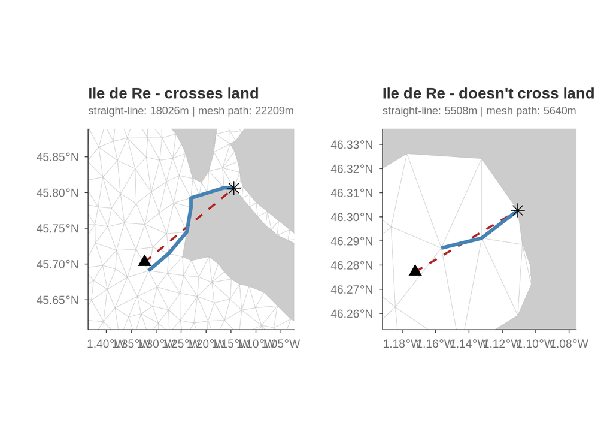

```r
sea_dist <- tar_read(sea_offshore_distance_to_mouth)
mouth_kept <- river_mouth_district |>
  filter(matched, district %in% district_kept) |>
  st_as_sf() |>
  st_transform(4326)
mouth_kept$node_id <- snap_to_sea_graph(mouth_kept, sea_graph)$node_id

sea_dist_sf <- sea_dist |>
  st_as_sf(coords = c("longitude", "latitude"), crs = 4326, remove = FALSE)
crossing_len <- straight_line_land_crossing(
  sea_dist_sf, mouth_kept, sea_mesh$land, district_kept
)
sea_dist_checked <- sea_dist |> left_join(crossing_len, by = "operation_id")

pick_pair <- function(xlim, ylim) {
  in_zoom <- sea_dist_checked |>
    filter(
      longitude >= xlim[1], longitude <= xlim[2],
      latitude >= ylim[1], latitude <= ylim[2]
    )
  crossing <- in_zoom |>
    filter(crossing_len_m > 100) |>
    arrange(desc(crossing_len_m)) |>
    slice(1)
  clean <- in_zoom |> filter(crossing_len_m == 0) |> slice(1)
  list(crossing = crossing, clean = clean)
}

pair_islands <- pick_pair(zoom_islands$xlim, zoom_islands$ylim)

plot_pair <- function(op_row, label) {
  path <- sea_mouth_path(op_row, mouth_kept, sea_graph)
  plot_sea_path_checkpoint(op_row, path, mesh_edges, sea_mesh$land, label)
}

p1 <- plot_pair(
  pair_islands$crossing, "Ile de Re - crosses land"
)
p2 <- plot_pair(
  pair_islands$clean, "Ile de Re - doesn't cross land"
)

p1 + p2
```

Where the straight line would cut across land, the mesh path detours around it and comes out longer; where it wouldn’t, the mesh path stays close to the straight-line distance.

#### Distance to river mouth: results

We present here results of the distance to river mouth for sea operations. First, here is the distributions of the distance to river mouth for sea-side and inland operations.

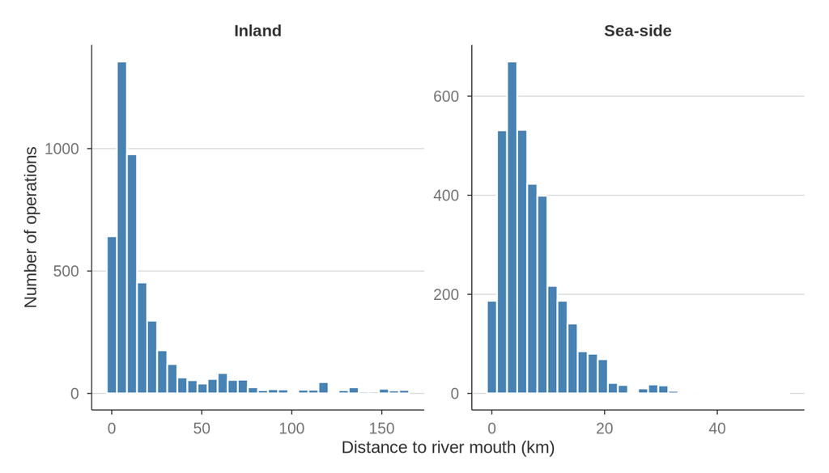

```r
sea_all_distance <- tar_read(distance_to_mouth) |>
  filter(survey != "river") |>
  mutate(method = if_else(inland, "Inland", "Sea-side"))

ggplot(sea_all_distance, aes(x = dist_mouth_m / 1000, fill = method)) +
  geom_histogram(bins = 30, color = "white") +
  scale_fill_manual(
    values = c(Inland = "steelblue", "Sea-side" = "steelblue"),
    guide = "none"
  ) +
  facet_wrap(~method, scales = "free") +
  labs(x = "Distance to river mouth (km)", y = "Number of operations")
```

We note that inland operations go deep in the large estuaries (such as Gironde), and can so can have large distance to river mouths (150 km). Sea-side operations are mostly coastal so the distance to river mouth remains small (smaller than 40 km).

```r
sea_all_distance |>
  group_by(method) |>
  summarise(
    n = n(),
    median_km = round(median(dist_mouth_m) / 1000, 1),
    max_km = round(max(dist_mouth_m) / 1000, 1)
  ) |>
  knitr::kable()
```

| method | n | median_km | max_km |
| --- | --- | --- | --- |
| Inland | 4686 | 9.8 | 162.4 |
| Sea-side | 3616 | 5.8 | 51.9 |

Here is a map with the operations colored by their distance to river mouth, with a zommed panel on the Gironde estuary where we can distinguish between inland and sea-side operations.

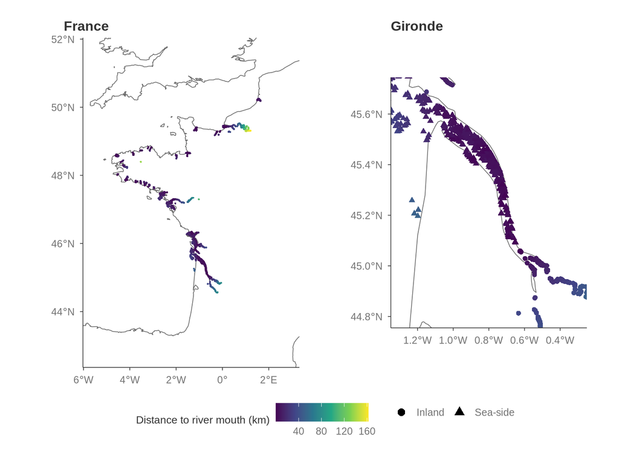

```r
p_main <- ggplot() +
  geom_sf(data = coastline(), linewidth = 0.3, color = "grey40") +
  geom_point(
    data = sea_all_distance,
    aes(longitude, latitude, color = dist_mouth_m / 1000),
    size = 0.5, shape = 16
  ) +
  scale_color_viridis_c(name = "Distance to river mouth (km)") +
  coord_sf(xlim = c(-5.6, 2.9), ylim = c(42.8, 51.6)) +
  labs(x = NULL, y = NULL, title = "France") +
  theme(panel.grid = element_blank())

p_zoom <- ggplot() +
  geom_sf(data = coastline(), linewidth = 0.3, color = "grey40") +
  geom_point(
    data = sea_all_distance,
    aes(longitude, latitude, color = dist_mouth_m / 1000, shape = method),
    size = 1.8
  ) +
  scale_color_viridis_c(name = "Distance to river mouth (km)") +
  scale_shape_manual(
    values = c(Inland = 16, "Sea-side" = 17), name = NULL
  ) +
  coord_sf(xlim = zoom_gironde$xlim, ylim = zoom_gironde$ylim) +
  labs(x = NULL, y = NULL, title = "Gironde") +
  guides(shape = guide_legend(override.aes = list(size = 3))) +
  theme(panel.grid = element_blank())

p_main + p_zoom +
  patchwork::plot_layout(guides = "collect", widths = c(1.3, 1))
```